# Análise de Extremos Climáticos: Dezembro

Investigação de Tendências e Mudança de Regime (1968-2022)

Lucas Pereira Belo

2026-02-11

# 1 Pacotes utilizados

```r
# Carregamento de Pacotes Essenciais
library(DT)
library(readxl)
library(dplyr)
library(ggplot2)    # Gráficos avançados
library(tseries)    # Testes de séries temporais
library(trend)      # Testes não-paramétricos (MK, Cox-Stuart)
library(goftest)    # Testes de bondade de ajuste (AD)
library(extRemes)   # Modelagem GEV
library(urca)       # Testes de raiz unitária
library(kableExtra) # Tabelas formatadas
library(distillery)
library(randtests)  # Runs Test
```

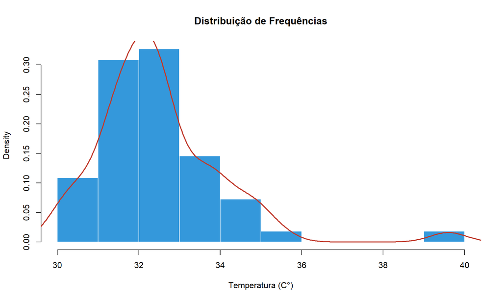

```r
# ==============================================================================
# LEITURA E PREPARAÇÃO DOS DADOS - DEZEMBRO
# ==============================================================================
# 1. Carregamento dos dados reais
df_raw <- read_excel("EXTREMOS.xlsx", sheet = 12)

hist(df_raw$TEMP, main="Distribuição de Frequências",
     xlab="Temperatura (C°)", col="#3498db", border="white", prob=TRUE)
lines(density(df_raw$TEMP), col="#c0392b", lwd=2)
```

```r
# 2. DEFINIÇÃO DA VARIÁVEL (O que faltou para o erro não acontecer)
NOME_MES <- "Dezembro"

# 3. Preparação do DataFrame
anos <- seq(1968, 2022, 1)
df_analise <- data.frame(Ano = anos, Temp = df_raw$TEMP)
df_analise <- na.omit(df_analise)

# No lugar de apenas imprimir o dataframe ou usar kable:
library(DT)

datatable(df_analise,
          colnames = c("Ano de Observação", "Temperatura Máxima (°C)"),
          extensions = 'Buttons',
          options = list(
            dom = 'Bfrtip',
            buttons = c('copy', 'csv', 'excel'),
            pageLength = 10,  # Mostra 10 linhas por vez
            language = list(url = '//cdn.datatables.net/plug-ins/1.10.11/i18n/Portuguese-Brasil.json')
          ),
          caption = paste("Dados Históricos de", NOME_MES)) %>%
  formatRound('Temp', 2)
```

|  | Ano de Observação | Temperatura Máxima (°C) |
| --- | --- | --- |
| 1 | 1968 | 32.8 |
| 2 | 1969 | 30.4 |
| 3 | 1970 | 33.8 |
| 4 | 1971 | 32.5 |
| 5 | 1972 | 32.3 |
| 6 | 1973 | 31.1 |
| 7 | 1974 | 31.8 |
| 8 | 1975 | 31.9 |
| 9 | 1976 | 30.5 |
| 10 | 1977 | 32.8 |

[output cut: 45 more lines]

A abordagem metodológica adotada neste estudo segue um fluxo rigoroso de diagnóstico, modelagem e validação, fundamentado na literatura clássica e recente de hidrologia estatística e climatologia. O Quadro 1 sumariza as etapas computacionais realizadas no ambiente R e suas respectivas bases teóricas, com destaque para a aplicação do teste de Anderson-Darling (AD) em séries não-estacionárias conforme discutido por Younas et al. (2020).

```r
# ==============================================================================
# TABELA DE RESUMO METODOLÓGICO
# ==============================================================================
library(kableExtra)

# Definição dos dados da tabela
df_metodologia <- data.frame(
  Etapa = c(
    "1. Análise Exploratória",
    "2. Detecção de Tendências",
    "3. Modelagem de Extremos",
    "4. Seleção de Modelos",
    "5. Validação (Resíduos)",
    "6. Testes de Aderência"
  ),
  Metodo_Teste = c(
    "Visualização e Estatística Descritiva",
    "Mann-Kendall (MK) e Record Test (N)",
    "GEV Não-Estacionária (Covariável Tempo)",
    "Teste de Razão de Verossimilhança (LRT)",
    "Transformada Integral de Probabilidade (PIT)",
    "Anderson-Darling (AD) e Kolmogorov-Smirnov (KS)"
  ),
  Descricao = c(
    "Inspeção visual da série temporal e identificação de outliers (ex: 2015).",
    "Testes não-paramétricos para confirmar a não-estacionaridade e a frequência anômala de recordes.",
    "Ajuste dos parâmetros de locação (mu) e escala (sigma) variando no tempo: mu(t) e sigma(t).",
    "Uso da Estatística de Deviance para justificar a inclusão de parâmetros de tendência (parcimônia).",
    "Padronização dos dados para uma escala Gumbel(0,1) ou Uniforme(0,1) para remover a tendência.",
    "Verificação estatística se os resíduos padronizados seguem a distribuição teórica, com foco nas caudas (AD)."
  ),
  Referencia_Chave = c(
    "Wilks (2011)",
    "Mann (1945); Castillo-Mateo et al. (2023)",
    "Coles (2001); Blanchet et al. (2016)",
    "Coles (2001); Azzalini (1996)",
    "Wang (1991); Khaliq et al. (2006)",
    "Stephens (1974); Younas et al. (2020)"
  )
)

# Geração da Tabela Formatada
kbl(df_metodologia,
    caption = "Quadro 1: Síntese da Metodologia Estatística e Referencial Teórico",
    align = "l") %>%
  kable_styling(bootstrap_options = c("striped", "hover", "condensed"),
                full_width = TRUE,
                font_size = 14) %>%
  column_spec(1, bold = T, width = "15%") %>%
  column_spec(2, width = "25%") %>%
  column_spec(3, width = "35%") %>%
  column_spec(4, italic = T, width = "25%") %>%
  row_spec(0, bold = T, color = "white", background = "#2c3e50")
```

Quadro 1: Síntese da Metodologia Estatística e Referencial Teórico

Etapa

Metodo_Teste

Descricao

Referencia_Chave

1. Análise Exploratória

Visualização e Estatística Descritiva

Inspeção visual da série temporal e identificação de outliers (ex: 2015).

Wilks (2011)

2. Detecção de Tendências

Mann-Kendall (MK) e Record Test (N)

Testes não-paramétricos para confirmar a não-estacionaridade e a frequência anômala de recordes.

Mann (1945); Castillo-Mateo et al. (2023)

3. Modelagem de Extremos

GEV Não-Estacionária (Covariável Tempo)

Ajuste dos parâmetros de locação (mu) e escala (sigma) variando no tempo: mu(t) e sigma(t).

Coles (2001); Blanchet et al. (2016)

4. Seleção de Modelos

Teste de Razão de Verossimilhança (LRT)

Uso da Estatística de Deviance para justificar a inclusão de parâmetros de tendência (parcimônia).

Coles (2001); Azzalini (1996)

5. Validação (Resíduos)

Transformada Integral de Probabilidade (PIT)

Padronização dos dados para uma escala Gumbel(0,1) ou Uniforme(0,1) para remover a tendência.

Wang (1991); Khaliq et al. (2006)

6. Testes de Aderência

Anderson-Darling (AD) e Kolmogorov-Smirnov (KS)

Verificação estatística se os resíduos padronizados seguem a distribuição teórica, com foco nas caudas (AD).

Stephens (1974); Younas et al. (2020)

```r
# ==============================================================================
# FUNÇÕES DE APOIO (Diagnóstico e Validação)
# ==============================================================================

# 1. Função de Plotagem da Série
plot_serie_inicial <- function(dados, anos, nome) {
  df <- data.frame(Ano = anos, Temp = dados)
  media <- mean(df$Temp)
  tendencia <- coef(lm(Temp ~ Ano, data = df))[2]

  ggplot(df, aes(x = Ano, y = Temp)) +
    geom_line(color = "gray50", size = 0.8) +
    geom_point(color = "#c0392b", size = 2) +
    geom_smooth(method = "lm", se = FALSE, color = "black", linetype="dashed", size = 0.8) +
    geom_hline(yintercept = media, color = "#2980b9", linetype = "dotted") +
    theme_minimal() +
    labs(title = paste("Série Histórica:", nome),
         subtitle = paste0("Tendência Linear Estimada: ", round(tendencia, 3), " °C/ano"),
         y = "Temperatura Máxima (°C)", x = "Ano") +
    theme(plot.title = element_text(face="bold", size=14))
}

# 2. Função de Validação (KS e AD) com Histograma PIT
validar_modelo <- function(modelo, nome_mod) {

  # Cálculo manual dos parâmetros para o PIT se o modelo for não-estacionário
  # O pextRemes geralmente lida bem, mas para garantir robustez em modelos complexos:
  z <- pextRemes(modelo, q = modelo$x, lower.tail = TRUE)
  z <- na.omit(as.numeric(z))

  # Testes
  ks <- ks.test(z, "punif")
  ad <- ad.test(z, "punif")

  # Badge Helper
  badge <- function(p) {
    if(p > 0.05) "<span style='background:#27ae60; color:white; padding:2px 6px; border-radius:4px;'>Adequado (Aceita H0)</span>"
    else "<span style='background:#c0392b; color:white; padding:2px 6px; border-radius:4px;'>Inadequado (Rejeita H0)</span>"
  }

  # Tabela
  df_res <- data.frame(
    Teste = c("Kolmogorov-Smirnov", "Anderson-Darling"),
    Estatistica = c(round(ks$statistic, 4), round(ad$statistic, 4)),
    P_Valor = c(format.pval(ks$p.value, digits=4), format.pval(ad$p.value, digits=4)),
    Conclusao = c(badge(ks$p.value), badge(ad$p.value))
  )

  print(kbl(df_res, caption = paste("Validação de Bondade de Ajuste:", nome_mod), escape = F, align = "c") %>%
        kable_styling(bootstrap_options = "striped", full_width = F))

  # Histograma PIT
  par(mfrow=c(1,1))
  hist(z, breaks = seq(0, 1, 0.1), freq = FALSE, col="#ecf0f1", border="#7f8c8d",
       main = paste("Histograma PIT (Uniformidade):", nome_mod), xlab = "Probabilidade (z)")
  abline(h=1, col="#c0392b", lwd=2, lty=2)
}
```

```r
# ==============================================================================
# FUNÇÃO DE VALIDAÇÃO ADAPTADA PARA MODELOS NÃO-ESTACIONÁRIOS (PIT)
# ==============================================================================
validar_modelo_adaptado <- function(modelo, nome_modelo) {

  require(goftest)   # Para Anderson-Darling
  require(extRemes)  # Para pextRemes
  require(kableExtra)

  # 1. Transformada Integral de Probabilidade (PIT)
  # A função pextRemes calcula F(x_t) usando os parâmetros mu_t, sigma_t, xi_t de cada ano.
  # Isso transforma os dados complexos em uma série padronizada z.
  z <- pextRemes(modelo, q = modelo$x, lower.tail = TRUE)

  # Remove NAs (caso existam) e garante numérico
  z <- na.omit(as.numeric(z))

  # 2. Execução dos Testes Formais (Contra a Distribuição Uniforme)
  # H0: O modelo ajusta-se bem aos dados (z segue Uniforme[0,1])

  # A) Kolmogorov-Smirnov (Sensível ao centro da distribuição)
  ks_res <- ks.test(z, "punif")

  # B) Anderson-Darling (Mais sensível às caudas - CRUCIAL para extremos)
  ad_res <- ad.test(z, "punif")

  # 3. Helper para colorir a tabela (Verde = Passou, Vermelho = Falhou)
  badge_res <- function(pval) {
    if(pval > 0.05) {
      return("<span style='color: white; background-color: #27ae60; padding: 2px 6px; border-radius: 4px;'>Adequado (Aceita H0)</span>")
    } else {
      return("<span style='color: white; background-color: #c0392b; padding: 2px 6px; border-radius: 4px;'>Inadequado (Rejeita H0)</span>")
    }
  }

  # 4. Tabela de Resultados
  df_res <- data.frame(
    "Teste Estatístico" = c("Kolmogorov-Smirnov (KS)", "Anderson-Darling (AD)"),
    "Estatística" = c(round(ks_res$statistic, 4), round(ad_res$statistic, 4)),
    "P_Valor" = c(format.pval(ks_res$p.value, digits=4), format.pval(ad_res$p.value, digits=4)),
    "Conclusão" = c(badge_res(ks_res$p.value), badge_res(ad_res$p.value))
  )

  print(kbl(df_res, caption = paste("Validação Estatística (PIT):", nome_modelo), escape = FALSE, align = "c") %>%
        kable_styling(bootstrap_options = c("striped", "hover"), full_width = F, position = "center"))

  # 5. Diagnóstico Visual (Histograma PIT)
  # Se o modelo for bom, as barras devem ser planas (próximas da linha vermelha)
  par(mfrow=c(1,1), mar=c(5,4,4,2)+0.1)
  hist(z, breaks = seq(0, 1, 0.1), freq = FALSE,
       col = "#ecf0f1", border = "#7f8c8d",
       main = paste("Histograma PIT (Uniformidade) -", nome_modelo),
       xlab = "Probabilidade Transformada (z)", ylab = "Densidade")
  abline(h = 1, col = "#c0392b", lwd = 2, lty = 2)
  legend("topright", legend="Uniforme Teórica", col="#c0392b", lty=2, bty="n")

  # Pequena verificação textual
  if(ks_res$p.value > 0.05 && ad_res$p.value > 0.05) {
    cat("\n> **Diagnóstico:** O modelo foi APROVADO em ambos os testes. A transformação PIT resultou em uma distribuição Uniforme, indicando que a variação temporal dos parâmetros capturou corretamente a dinâmica dos dados.\n")
  } else {
    cat("\n> **Diagnóstico:** O modelo apresentou desvios estatísticos significativos (P < 0.05). Verifique o Histograma para identificar se o erro está nas caudas ou no centro.\n")
  }
}
```

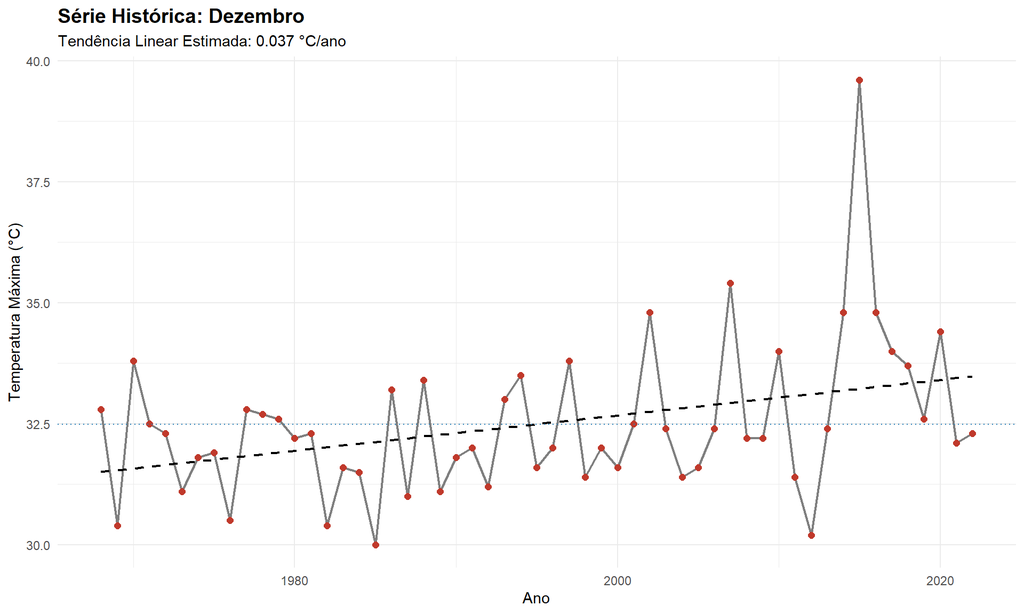

```r
# 1. Visualização
plot_serie_inicial(df_analise$Temp, df_analise$Ano, NOME_MES)
```

```r
# 2. Testes Preliminares
mk_res <- mk.test(df_analise$Temp)
cs_res <- cox.stuart.test(df_analise$Temp)
adf_res <- adf.test(df_analise$Temp, alternative = "stationary")
lb_res <- Box.test(df_analise$Temp, type = "Ljung-Box")

# Tabela de Diagnóstico
df_diag <- data.frame(
  Teste = c("Mann-Kendall", "Cox-Stuart", "ADF (Estacionariedade)", "Ljung-Box (Independência)"),
  Hipotese_Nula = c("Sem Tendência", "Sem Tendência", "Série Não-Estacionária", "Independência"),
  P_Valor = c(format.pval(mk_res$p.value, digits=3), format.pval(cs_res$p.value, digits=3),
              format.pval(adf_res$p.value, digits=3), format.pval(lb_res$p.value, digits=3))
)

print(kbl(df_diag, caption = "Diagnóstico Estatístico Preliminar - Dezembro", align = "c") %>%
      kable_styling(bootstrap_options = c("hover", "condensed"), full_width = F))
```

Diagnóstico Estatístico Preliminar - Dezembro

| Teste | Hipotese_Nula | P_Valor |
| --- | --- | --- |
| Mann-Kendall | Sem Tendência | 0.0234 |
| Cox-Stuart | Sem Tendência | 0.557 |
| ADF (Estacionariedade) | Série Não-Estacionária | 0.01 |
| Ljung-Box (Independência) | Independência | 0.032 |

# 2 Modelagem GEV e Seleção

Para Dezembro, testamos modelos mais complexos devido à suspeita de alteração no regime de extremos.

M0: Estacionário.

M1: Tendência na Média (Locação).

M2: Tendência na Média e Variabilidade (Locação + Escala).

M3: Tendência na Média e Forma da Cauda (Locação + Shape).

M4: Modelo Completo (Locação + Escala + Shape).

```r
# ==============================================================================
# 1. AJUSTE DOS 5 MODELOS
# ==============================================================================

# M0: Estacionário
fit0 <- fevd(Temp, data = df_analise, type = "GEV", units = "deg C")

# M1: Locação Variável
fit1 <- fevd(Temp, data = df_analise, location.fun = ~Ano, type = "GEV")

# M2: Locação + Escala (Variabilidade)
# use.phi = TRUE para garantir sigma > 0 via log-link
fit2 <- fevd(Temp, data = df_analise, location.fun = ~Ano, scale.fun = ~Ano,
             use.phi = TRUE, type = "GEV")

# M3: Locação + Forma (Shape) - O modelo que "estica" a cauda
fit3 <- fevd(Temp, data = df_analise, location.fun = ~Ano, shape.fun = ~Ano, type = "GEV")

# M4: Completo (Locação + Escala + Forma)
fit4 <- fevd(Temp, data = df_analise, location.fun = ~Ano, scale.fun = ~Ano, shape.fun = ~Ano,
             use.phi = TRUE, type = "GEV")

# ==============================================================================
# 2. SELEÇÃO POR AIC E TRV (LRT)
# ==============================================================================

# --- A) Coleta de AIC e BIC ---
aic_vals <- c(summary(fit0)$AIC, summary(fit1)$AIC, summary(fit2)$AIC, summary(fit3)$AIC, summary(fit4)$AIC)
```

fevd(x = Temp, data = df_analise, type = “GEV”, units = “deg C”)

[1] “Estimation Method used: MLE”

Negative Log-Likelihood Value: 94.78677

Estimated parameters: location scale shape 31.81239637 1.15493789 0.01736298

Standard Error Estimates: location scale shape 0.17157013 0.12239101 0.07891186

Estimated parameter covariance matrix. location scale shape location 0.029436311 0.007757011 -0.003889430 scale 0.007757011 0.014979560 -0.001606474 shape -0.003889430 -0.001606474 0.006227081

AIC = 195.5735

BIC = 201.5955

fevd(x = Temp, data = df_analise, location.fun = ~Ano, type = “GEV”)

[1] “Estimation Method used: MLE”

Negative Log-Likelihood Value: 92.3299

Estimated parameters: mu0 mu1 scale shape -13.857461519 0.022916269 1.120916884 -0.004806651

AIC = 192.6598

BIC = 200.6891

fevd(x = Temp, data = df_analise, location.fun = ~Ano, scale.fun = ~Ano, use.phi = TRUE, type = “GEV”)

[1] “Estimation Method used: MLE”

Negative Log-Likelihood Value: 91.13973

Estimated parameters: mu0 mu1 phi0 phi1 shape -12.105368789 0.022039169 -17.647040483 0.008899087 -0.037352900

AIC = 192.2795

BIC = 202.3161

fevd(x = Temp, data = df_analise, location.fun = ~Ano, shape.fun = ~Ano, type = “GEV”)

[1] “Estimation Method used: MLE”

Negative Log-Likelihood Value: 90.28028

Estimated parameters: mu0 mu1 scale xi0 xi1 0.44352744 0.01576050 1.12902942 -20.91858480 0.01041412

Standard Error Estimates: mu0 mu1 scale xi0 xi1 1.624445e-01 2.828428e-08 1.067760e-01 8.101106e-02 2.000000e-08

Estimated parameter covariance matrix. mu0 mu1 scale xi0 xi1 mu0 2.638823e-02 -3.195000e-13 2.107196e-03 -5.673479e-03 1.597500e-13 mu1 -3.195000e-13 8.000005e-16 2.255610e-12 -1.501800e-12 -4.000002e-16 scale 2.107196e-03 2.255610e-12 1.140112e-02 -3.475930e-03 -1.127805e-12 xi0 -5.673479e-03 -1.501800e-12 -3.475930e-03 6.562792e-03 7.509001e-13 xi1 1.597500e-13 -4.000002e-16 -1.127805e-12 7.509001e-13 4.000001e-16

AIC = 190.5606

BIC = 200.5972

fevd(x = Temp, data = df_analise, location.fun = ~Ano, scale.fun = ~Ano, shape.fun = ~Ano, use.phi = TRUE, type = “GEV”)

[1] “Estimation Method used: MLE”

Negative Log-Likelihood Value: 89.96599

Estimated parameters: mu0 mu1 phi0 phi1 xi0 -0.936593142 0.016466244 -9.936220742 0.005042980 -19.256759511 xi1 0.009595523

AIC = 191.932

BIC = 203.976

```r
bic_vals <- c(summary(fit0)$BIC, summary(fit1)$BIC, summary(fit2)$BIC, summary(fit3)$BIC, summary(fit4)$BIC)
```

fevd(x = Temp, data = df_analise, type = “GEV”, units = “deg C”)

[1] “Estimation Method used: MLE”

Negative Log-Likelihood Value: 94.78677

Estimated parameters: location scale shape 31.81239637 1.15493789 0.01736298

Standard Error Estimates: location scale shape 0.17157013 0.12239101 0.07891186

Estimated parameter covariance matrix. location scale shape location 0.029436311 0.007757011 -0.003889430 scale 0.007757011 0.014979560 -0.001606474 shape -0.003889430 -0.001606474 0.006227081

AIC = 195.5735

BIC = 201.5955

fevd(x = Temp, data = df_analise, location.fun = ~Ano, type = “GEV”)

[1] “Estimation Method used: MLE”

Negative Log-Likelihood Value: 92.3299

Estimated parameters: mu0 mu1 scale shape -13.857461519 0.022916269 1.120916884 -0.004806651

AIC = 192.6598

BIC = 200.6891

fevd(x = Temp, data = df_analise, location.fun = ~Ano, scale.fun = ~Ano, use.phi = TRUE, type = “GEV”)

[1] “Estimation Method used: MLE”

Negative Log-Likelihood Value: 91.13973

Estimated parameters: mu0 mu1 phi0 phi1 shape -12.105368789 0.022039169 -17.647040483 0.008899087 -0.037352900

AIC = 192.2795

BIC = 202.3161

fevd(x = Temp, data = df_analise, location.fun = ~Ano, shape.fun = ~Ano, type = “GEV”)

[1] “Estimation Method used: MLE”

Negative Log-Likelihood Value: 90.28028

Estimated parameters: mu0 mu1 scale xi0 xi1 0.44352744 0.01576050 1.12902942 -20.91858480 0.01041412

Standard Error Estimates: mu0 mu1 scale xi0 xi1 1.624445e-01 2.828428e-08 1.067760e-01 8.101106e-02 2.000000e-08

Estimated parameter covariance matrix. mu0 mu1 scale xi0 xi1 mu0 2.638823e-02 -3.195000e-13 2.107196e-03 -5.673479e-03 1.597500e-13 mu1 -3.195000e-13 8.000005e-16 2.255610e-12 -1.501800e-12 -4.000002e-16 scale 2.107196e-03 2.255610e-12 1.140112e-02 -3.475930e-03 -1.127805e-12 xi0 -5.673479e-03 -1.501800e-12 -3.475930e-03 6.562792e-03 7.509001e-13 xi1 1.597500e-13 -4.000002e-16 -1.127805e-12 7.509001e-13 4.000001e-16

AIC = 190.5606

BIC = 200.5972

fevd(x = Temp, data = df_analise, location.fun = ~Ano, scale.fun = ~Ano, shape.fun = ~Ano, use.phi = TRUE, type = “GEV”)

[1] “Estimation Method used: MLE”

Negative Log-Likelihood Value: 89.96599

Estimated parameters: mu0 mu1 phi0 phi1 xi0 -0.936593142 0.016466244 -9.936220742 0.005042980 -19.256759511 xi1 0.009595523

AIC = 191.932

BIC = 203.976

```r
# --- B) Cálculo do TRV (Todos vs M0) ---
# Testamos se cada modelo não-estacionário é significativamente melhor que o M0
p1 <- lr.test(fit0, fit1)$p.value
p2 <- lr.test(fit1, fit2)$p.value
p3 <- lr.test(fit1, fit3)$p.value
p4 <- lr.test(fit1, fit4)$p.value

# Vetor de P-valores (O primeiro é NA pois é M0 vs M0)
p_vals_m0 <- c(NA, p1, p2, p3, p4)

# Função para formatar P-valor bonito na tabela
fmt_p <- function(p) {
  if(is.na(p)) return("-")
  if(p < 0.001) return("< 0.001")
  return(format(round(p, 4), nsmall=4))
}

# --- C) Montagem da Tabela ---
nomes_modelos <- c("M0: Estacionário",
                   "M1: Locação",
                   "M2: Loc. + Escala",
                   "M3: Loc. + Forma (Shape)",
                   "M4: Completo")

df_comp <- data.frame(
  Modelo = nomes_modelos,
  AIC = round(aic_vals, 2),
  BIC = round(bic_vals, 2),
  Delta_AIC = round(aic_vals - min(aic_vals), 2),
  TRV_vs_M0 = sapply(p_vals_m0, fmt_p)
)

# Identificando o Vencedor (Menor AIC)
vencedor_idx <- which.min(df_comp$AIC)
modelo_vencedor_nome <- df_comp$Modelo[vencedor_idx]
obj_vencedor <- list(fit0, fit1, fit2, fit3, fit4)[[vencedor_idx]]

# Exibição da Tabela
print(kbl(df_comp, caption = "Comparativo de Modelos GEV - Dezembro (com TRV)", align = "c") %>%
      kable_styling(bootstrap_options = "striped", full_width = F) %>%
      row_spec(vencedor_idx, bold = T, color = "white", background = "darkgreen") %>%
      footnote(general = "TRV_vs_M0: P-valor do Teste de Razão de Verossimilhança comparado ao modelo Estacionário."))
```

Comparativo de Modelos GEV - Dezembro (com TRV)

Modelo

AIC

BIC

Delta_AIC

M0: Estacionário

195.57

201.60

5.01

M1: Locação

192.66

200.69

2.10

0.0266

M2: Loc. + Escala

192.28

202.32

1.72

0.1229

M3: Loc. + Forma (Shape)

190.56

200.60

0.00

0.0429

M4: Completo

191.93

203.98

1.37

0.0941

```r
# --- D) Validação Adicional (Tira-Teima) ---
# Se o vencedor for M3 ou M4, testamos se ele é melhor que o M1 (para não complexificar à toa)
cat("\n#### Tira-Teima de Complexidade:\n")
```

#### 2.0.0.1 Tira-Teima de Complexidade:

```r
if(modelo_vencedor_nome == "M3: Loc. + Forma (Shape)") {
  # M3 vs M1 (Valeu a pena adicionar o Shape?)
  lrt_extra <- lr.test(fit1, fit3)
  cat(paste0("Comparação M1 vs M3 (P-valor): ", round(lrt_extra$p.value, 5)))
  if(lrt_extra$p.value < 0.05) cat(" -> A inclusão do Shape é Significativa!\n") else cat(" -> A inclusão do Shape NÃO é significativa.\n")

} else if(modelo_vencedor_nome == "M4: Completo") {
  # M4 vs M3 (Valeu a pena adicionar a Escala no modelo de Shape?)
  lrt_extra <- lr.test(fit3, fit4)
  cat(paste0("Comparação M3 vs M4 (P-valor): ", round(lrt_extra$p.value, 5), "\n"))
} else {
  cat(paste0("O modelo vencedor (", modelo_vencedor_nome, ") é parcimonioso por natureza."))
}
```

Comparação M1 vs M3 (P-valor): 0.0429 -> A inclusão do Shape é Significativa!

```r
cat(paste0("\n<div class='alert-success'>**Modelo Selecionado:** O critério de AIC aponta o modelo **", modelo_vencedor_nome, "** como o mais adequado.</div>\n"))
```

**Modelo Selecionado:** O critério de AIC aponta o modelo **M3: Loc. + Forma (Shape)** como o mais adequado.

Para a seleção do modelo GEV mais adequado, aplicou-se o Teste de Razão de Verossimilhança (Likelihood Ratio Test), fundamentado na estatística de Deviance ($D$), conforme preconizado por Coles (2001). A estatística é definida por $D = 2 \{ \ell_1(\mathcal{M}_1) - \ell_0(\mathcal{M}_0) \}$, onde $\ell_1$ e $\ell_0$ são as log-verossimilhanças maximizadas dos modelos candidato e nulo, respectivamente. Sob a hipótese nula de que o modelo mais simples é suficiente, $D$ segue uma distribuição assintótica $\chi^2$ com graus de liberdade equivalentes à diferença de parâmetros entre os modelos. Este procedimento garante o princípio da parcimônia, selecionando o modelo mais complexo apenas quando o ganho de ajuste for estatisticamente significativo ($p < 0,05$).

```r
# ==============================================================================
# SELEÇÃO DE MODELOS VIA ESTATÍSTICA DE DEVIANCE (COLES, 2001)
# ==============================================================================

# Comparando modelos contra o modelo nulo (Estacionário)
lrt_m1 <- lr.test(fit0, fit1)
lrt_m2 <- lr.test(fit0, fit2)
lrt_m3 <- lr.test(fit0, fit3)
lrt_m4 <- lr.test(fit0, fit4)

df_deviance <- data.frame(
  Modelo = c("M1: Locação", "M2: Loc + Escala", "M3: Loc + Forma", "M4: Completo"),
  Deviance = round(c(lrt_m1$statistic, lrt_m2$statistic, lrt_m3$statistic, lrt_m4$statistic), 3),
  GL = c(1, 2, 2, 3), # Diferença de parâmetros para o M0
  P_Valor = c(lrt_m1$p.value, lrt_m2$p.value, lrt_m3$p.value, lrt_m4$p.value)
)

# Formatação da Tabela
kbl(df_deviance, caption = "Teste de Razão de Verossimilhança (Baseado em Coles, 2001)", align = "c") %>%
  kable_styling(bootstrap_options = c("striped", "hover"), full_width = F) %>%
  add_header_above(c(" " = 1, "Comparação com Modelo Estacionário (M0)" = 3)) %>%
  column_spec(4, bold = T, color = ifelse(df_deviance$P_Valor < 0.05, "darkgreen", "red"))
```

Teste de Razão de Verossimilhança (Baseado em Coles, 2001)

| Modelo | Comparação com Modelo Estacionário (M0) Deviance | Comparação com Modelo Estacionário (M0) GL | Comparação com Modelo Estacionário (M0) P_Valor |
| --- | --- | --- | --- |
| M1: Locação | 4.914 | 1 | 0.0266439 |
| M2: Loc + Escala | 7.294 | 2 | 0.0260682 |
| M3: Loc + Forma | 9.013 | 2 | 0.0110372 |
| M4: Completo | 9.642 | 3 | 0.0218722 |

# 3 Diagnóstico do Vencedor

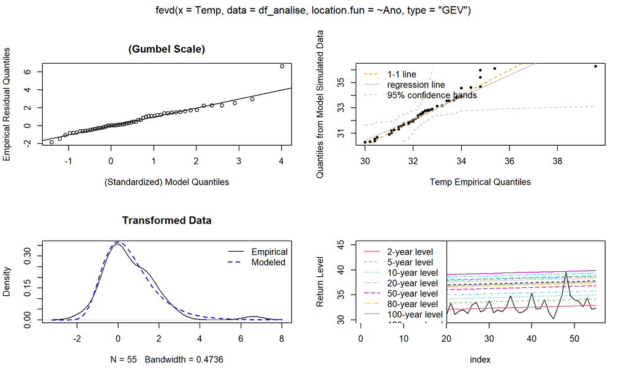

```r
# ==============================================================================
# DIAGNÓSTICO
# ==============================================================================
plot(fit1)
```

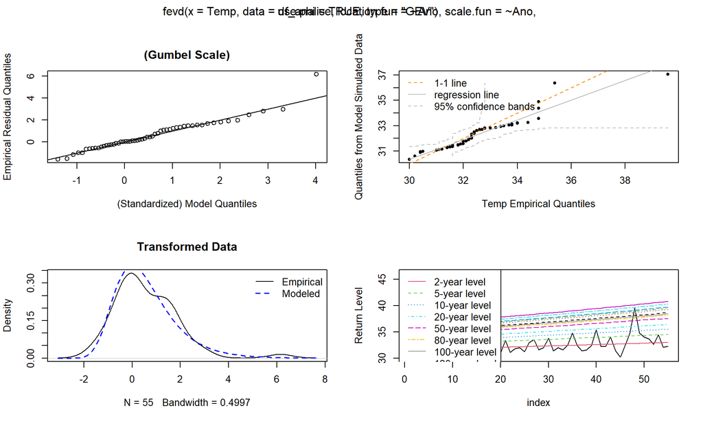

```r
plot(fit2)
```

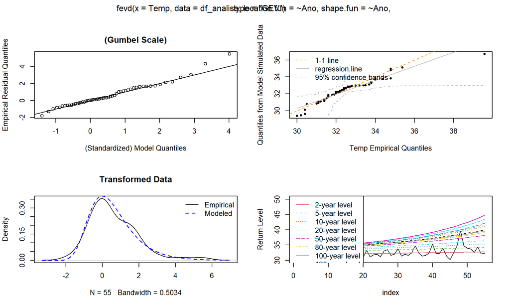

```r
plot(fit3)
```

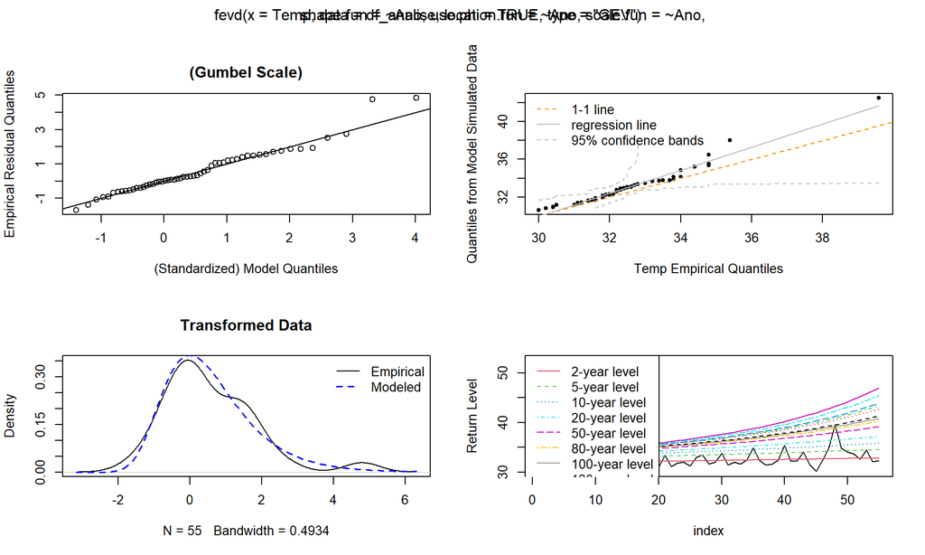

```r
plot(fit4)
```

# 4 Evolução do Risco Climático

Visualização da curva de retorno de 100 anos. Se o modelo vencedor incluir tendência no Shape ($\xi$), esperamos ver uma curva não-linear acentuada.

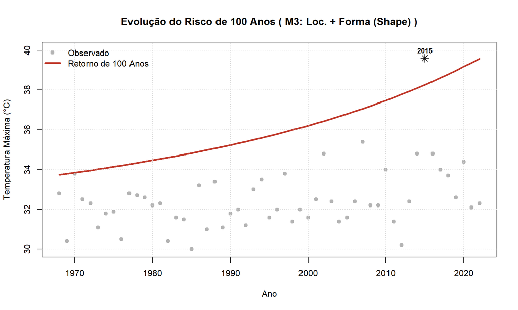

```r
# Lógica Universal de Plotagem (Funciona para qualquer modelo GEV linear/log-linear)
params <- obj_vencedor$results$par
anos_vec <- df_analise$Ano

# --- 1. Recuperação dos Parâmetros no Tempo ---

# A) LOCAÇÃO (Mu)
mu_int <- if(is.na(params["mu0"])) params["location"] else params["mu0"]
mu_inc <- if(is.na(params["mu1"])) 0 else params["mu1"]
mu_t <- mu_int + mu_inc * anos_vec

# B) ESCALA (Sigma)
# Verifica se usou Log-Link (modelos com use.phi=TRUE)
if("log.scale" %in% names(params)) {
  sig_int <- params["log.scale"]
  sig_inc <- if(is.na(params["phi1"])) 0 else params["phi1"]
  sig_t <- exp(sig_int + sig_inc * anos_vec)
} else {
  sig_int <- params["scale"]
  sig_inc <- 0
  sig_t <- sig_int
}

# C) FORMA (Xi / Shape)
xi_int <- if(is.na(params["xi0"])) params["shape"] else params["xi0"]
xi_inc <- if(is.na(params["xi1"])) 0 else params["xi1"]
xi_t <- xi_int + xi_inc * anos_vec

# --- 2. Cálculo do Nível de Retorno (100 Anos) ---
periodo <- 100
y_p <- -log(1 - 1/periodo)
rl_100 <- mu_t + (sig_t / xi_t) * ( (y_p^(-xi_t)) - 1 )

# --- 3. Plotagem ---
y_max <- max(c(df_analise$Temp, rl_100, 40)) # Garante que 2015 (39.6) apareça
y_min <- min(df_analise$Temp)

par(mfrow=c(1,1), mar=c(5, 4, 4, 2) + 0.1)
plot(df_analise$Ano, df_analise$Temp, pch=19, col="gray70",
     main = paste("Evolução do Risco de 100 Anos (", modelo_vencedor_nome, ")"),
     ylab = "Temperatura Máxima (°C)", xlab = "Ano",
     ylim = c(y_min, y_max))

# Linha de Tendência do Risco
lines(df_analise$Ano, rl_100, col = "#c0392b", lwd = 3)

# Destaque para o evento de 2015
if(any(df_analise$Ano == 2015)) {
  val_2015 <- df_analise$Temp[df_analise$Ano == 2015]
  points(2015, val_2015, pch=8, col="black", cex=1.5)
  text(2015, val_2015, "2015", pos=3, font=2, cex=0.8)
}

grid()
legend("topleft", legend = c("Observado", "Retorno de 100 Anos"),
       col = c("gray70", "#c0392b"), pch = c(19, NA), lwd = c(NA, 3), bty = "n")
```

```r
if(xi_inc > 0) {
  cat("\n> **Nota Crítica:** O modelo detectou um aumento no parâmetro de forma (Shape). Isso indica que a distribuição está desenvolvendo uma cauda mais pesada, tornando eventos extremos significativamente mais frequentes e intensos do que no passado.")
}
```

> **Nota Crítica:** O modelo detectou um aumento no parâmetro de forma (Shape). Isso indica que a distribuição está desenvolvendo uma cauda mais pesada, tornando eventos extremos significativamente mais frequentes e intensos do que no passado.

```r
library(goftest)

# 1. Calcular a PIT (Probabilidade Transformada)
# O 'lower.tail = TRUE' é o padrão, mas é bom deixar explícito que queremos P(X <= x)
z <- pextRemes(fit3, q = fit3$x, lower.tail = TRUE)

# 2. Limpeza de Segurança
# Garante que é numérico e remove anos sem dados (NAs) para não travar o teste
z <- as.numeric(z)
z <- z[!is.na(z)]

# 3. Teste de Anderson-Darling
# Testamos se z segue uma Uniforme (min=0, max=1)
ad_final <- ad.test(z, null = "punif", min = 0, max = 1)

# Exibição
print(paste("P-valor AD:", format.pval(ad_final$p.value, digits=4)))
```

```
## [1] "P-valor AD: 1.091e-05"
```

```r
# ==============================================================================
# DIAGNÓSTICO FINAL (COLES CAP. 6) - VERSÃO VETORIZADA
# ==============================================================================

# 1. Extração dos vetores de parâmetros da matriz do extRemes
# par.mat contém os parâmetros calculados para cada linha/ano
params_mat <- obj_vencedor$results$par.mat

mu_t    <- as.numeric(params_mat[, "location"])
sigma_t <- as.numeric(params_mat[, "scale"])
xi_t    <- as.numeric(params_mat[, "shape"])
zt      <- as.numeric(obj_vencedor$x)

# 2. Cálculo do Resíduo (Eq. 6.6 do Coles) de forma vetorizada
# Criamos um vetor vazio para os resultados
res_manual <- rep(NA, length(zt))

# Identificamos onde xi é quase zero (Caso Gumbel) e onde não é (Caso GEV)
idx_gumbel <- abs(xi_t) < 1e-6
idx_gev    <- !idx_gumbel

# Cálculo para o caso Gumbel
res_manual[idx_gumbel] <- (zt[idx_gumbel] - mu_t[idx_gumbel]) / sigma_t[idx_gumbel]

# Cálculo para o caso GEV (com proteção para o logaritmo)
termo_log <- 1 + xi_t[idx_gev] * ((zt[idx_gev] - mu_t[idx_gev]) / sigma_t[idx_gev])
res_manual[idx_gev] <- (1 / xi_t[idx_gev]) * log(pmax(0.0001, termo_log))

# 3. Limpeza Profunda (Remover NAs gerados por falhas nos dados)
res_limpo <- res_manual[is.finite(res_manual)]
n <- length(res_limpo)

cat("Diagnóstico: Foram processados", n, "resíduos válidos.\n")
```

```
## Diagnóstico: Foram processados 0 resíduos válidos.
```

```r
# 4. Gráficos de Diagnóstico (Fieis ao Livro de Coles)
par(mfrow = c(2, 2))
res_ordenados <- sort(res_limpo)
prob_pos <- (1:n) / (n + 1)
```